# Forschungspraktikum 1+2: Computational Social Science

Tutorial 04: Sentiment Analysis

Dr. Christian Czymara

In this tutorial, we will work with the [Large Movie Review Dataset v1.0](https://ai.stanford.edu/~amaas/data/sentiment/), provided by Andrew Maas and colleagues (2011). This dataset includes 50,000 user-written movie reviews.

Reference: Andrew L. Maas, Raymond E. Daly, Peter T. Pham, Dan Huang, Andrew Y. Ng, and Christopher Potts. (2011). [Learning Word Vectors for Sentiment Analysis](https://ai.stanford.edu/~amaas/papers/wvSent_acl2011.pdf). *The 49th Annual Meeting of the Association for Computational Linguistics (ACL 2011)*.

## 0. Getting Started

Ensure the necessary R packages are installed and loaded. `readtext` helps import text files, `quanteda`, `tidytext`, `tidyr`, and `dplyr` assist with data processing, and `ggplot2` and `wordcloud` are used for visualization.

```r
packages <- c(
  "readtext",     # Reads text files for easy import into R
  "quanteda",     # Text data preparation and analysis, creating tokens and DFMs
  "dplyr",        # Data manipulation, used for filtering, selecting, and summarizing
  "tidytext",     # Text mining, unnesting tokens and joining sentiment lexicons
  "tidyr",        # Reshaping data, useful for preparing sentiment counts
  "wordcloud",    # Create word clouds
  "ggplot2"       # Data visualization for plots and sentiment distributions
  )

# install if necessary
install.packages(setdiff(packages, rownames(installed.packages())))

# load
lapply(packages, library, character.only = TRUE)
```

[output not shown]

## 1. Data Preparation

### a) Data Import

Download the data set from this [repository](https://raw.githubusercontent.com/SK7here/Movie-Review-Sentiment-Analysis/master/IMDB-Dataset.csv) and import it into your R environment. Assign to an object called `movie_ratings_raw`.

```r
ratings_url <- "https://raw.githubusercontent.com/SK7here/Movie-Review-Sentiment-Analysis/master/IMDB-Dataset.csv"

movie_ratings_raw <- read.csv(ratings_url)

# Count the number of texts that contain either "/10" or "out of 10"
# sum(grepl("/10|out of 10", movie_ratings_raw$text))
```

### b) Preprocessing

Run the following code to preprocess the data. Are there any additional preprocessing steps you would consider applying?

```r
movie_ratings <- corpus(movie_ratings_raw$review)                # Create corpus

movie_ratings_dfm <- dfm(tokens(movie_ratings))                  # Create DFM

movie_ratings_df <- data.frame(text = as.character(movie_ratings)) %>%
    mutate(doc_id = paste0("text", row_number()))                # Add document IDs

movie_ratings_clean <- movie_ratings_df %>%
    unnest_tokens(word, text)                                    # Tokenize text as data frame
```

## 2. Sentiment Analysis

### a) Get Dictionary

The first sentiment analysis will be based on the “bing” dictionary from [Bing Liu and colleagues](https://juliasilge.github.io/tidytext/reference/sentiments.html) as provided by the `tidytext` package. Use the `get_sentiments()` function to access this dictionary. How many positive and negative words does this dictionary include?

```r
# Get the sentiment lexicon
bing_lexicon <- get_sentiments("bing")

table(bing_lexicon$sentiment)
```

```
##
## negative positive
##     4781     2005
```

### b) Apply Dictionary to Texts

Now, in each review, count the occurrences of the positive and negative terms provided by the dictionary. Adapt the following code to achieve this:

```r
reviews_sentiment_bing <- movie_ratings_clean %>%
    inner_join(..., by = ...) %>%
    count(...) %>%
    spread(...)
```

What does each step do? Examine the `reviews_sentiment_bing` object.

```r
reviews_sentiment_bing <- movie_ratings_clean %>%
    inner_join(bing_lexicon, by = "word") %>%
    count(doc_id, sentiment) %>%
    spread(sentiment, n)

# View sentiments
head(reviews_sentiment_bing)
```

```
##      doc_id negative positive
## 1     text1       18       11
## 2    text10        1        5
## 3   text100       13       21
## 4  text1000       15       20
## 5 text10000        6        5
## 6 text10001       12       11
```

### c) Examine Positive and Negative Reviews

On average, are there more positive or more negative terms in the reviews? Visualize the relationship between positive and negative terms using a scatter plot.

```r
mean(reviews_sentiment_bing$positive, na.rm = T)
```

```
## [1] 10.16765
```

```r
mean(reviews_sentiment_bing$negative, na.rm = T)
```

```
## [1] 9.833454
```

```r
cor(reviews_sentiment_bing$positive, reviews_sentiment_bing$negative, use = "complete.obs")
```

```
## [1] 0.5584529
```

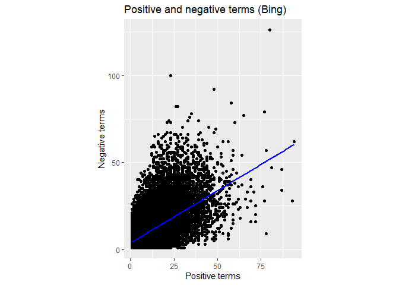

```r
ggplot(reviews_sentiment_bing, aes(x = positive, y = negative)) +
    geom_point() +
    geom_smooth(method = "lm", color = "blue", se = FALSE) +
    labs(title = "Positive and negative terms (Bing)",
         x = "Positive terms",
         y = "Negative terms") +
  coord_fixed(ratio=1)
```

### d) Word Clouds of Positive and Negative Terms

Generate two word clouds, one for the most frequent positive terms and one for the most frequent negative terms. Adapt the following code to do this:

```r
movie_ratings_clean %>%
    inner_join(filter(bing_lexicon, sentiment == ...), by = ...) %>%
    count(...) %>%
    with(wordcloud(...))
```

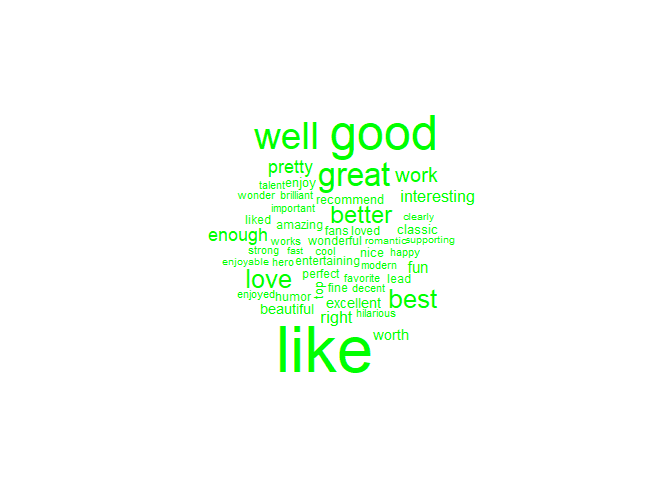

```r
# Positive word cloud
movie_ratings_clean %>%
    inner_join(filter(bing_lexicon, sentiment == "positive"), by = "word") %>%
    count(word, sort = TRUE) %>%
    with(wordcloud(word, n, max.words = 50, colors = "green"))
```

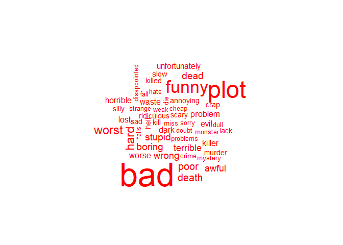

```r
# Negative word cloud
movie_ratings_clean %>%
    inner_join(filter(bing_lexicon, sentiment == "negative"), by = "word") %>%
    count(word, sort = TRUE) %>%
    with(wordcloud(word, n, max.words = 50, colors = "red"))
```

### e) Calculate Sentiment Score

Calculate the sentiment score for each review by subtracting the number of negative terms from the number of positive terms. What is the average sentiment score across all reviews?

```r
reviews_sentiment_bing$sentiment <- reviews_sentiment_bing$positive - reviews_sentiment_bing$negative

mean(reviews_sentiment_bing$sentiment, na.rm = TRUE)
```

```
## [1] 0.4110111
```

## 3. Validation

Validation is essential in sentiment analysis to ensure accuracy and reliability. Here, we will first examine example reviews and then compare these results to any star ratings mentioned within the text, which could be considered the “true value”.

### a) Example Reviews

Identify the most positive and most negative review based on the dictionary’s sentiment scores. Examine the content of these reviews. Do you think the dictionary-based sentiment classification aligns well with the actual tone?

```r
# most positive review (highest sentiment score)
movie_ratings_df$text[which.max(reviews_sentiment_bing$sentiment)]
```

```
## [1] "Jane Russell proved to be a delightful musical-comedy performer in the similarly titled \"Gentlemen Prefer Blondes\"\u0085 but, sadly, this film squanders those skills. There is a budget, and nice Paris photography, but the film just doesn't work. Ms. Russell seems to be playing Marilyn Monr…
```

```r
# most negative review (highest lowest score)
movie_ratings_df$text[which.min(reviews_sentiment_bing$sentiment)]
```

```
## [1] "This movie starts out great, and sucks you in. Most acting is good until Patrick Swayze (with his Texas Twang- everyone else sounds British-like even the Muslim) shows up, and proves that he can't act. You can live with that until the first fight scene where all they all fall to pieces. Why …
```

### b) Extract Star Ratings

While the dataset lacks explicit star ratings, some reviews contain an informal rating within the text (e.g., “7/10” or “7 out of 10”). Use the following code to extract these ratings from the review texts:

```r
# Extract the number preceding "/10" or "out of 10"
movie_ratings_df$rating <- as.numeric(stringr::str_extract(movie_ratings_df$text, "(\\d+)(?=\\s*/10|\\s*out of 10)"))

# Filter ratings between 0 and 10
movie_ratings_df$rating <- ifelse(movie_ratings_df$rating >= 0 & movie_ratings_df$rating <= 10, movie_ratings_df$rating, NA)

# Verify the range of ratings after filtering
range(movie_ratings_df$rating, na.rm = TRUE)
```

```
## [1]  0 10
```

How many reviews include an explicit rating?

```r
table(is.na(movie_ratings_df$rating))
```

```
##
## FALSE  TRUE
##  4330 45670
```

```r
prop.table(table(is.na(movie_ratings_df$rating)))
```

```
##
##  FALSE   TRUE
## 0.0866 0.9134
```

### c) Correlation of Ratings and Classification

Let’s calculate the correlation between the extracted ratings and the sentiment scores from the Bing dictionary.

First, use `dplyr`’s `inner_join()` function to merge the star ratings and sentiment scores into a single data frame, joining them by their shared `doc_id` (see exercise 2.b) above).

Then, calculate the correlation between the star ratings and the sentiment scores. What do you conclude?

```r
# Merge movie_ratings_df and reviews_sentiment_bing by "doc_id"
merged_df <- inner_join(movie_ratings_df, reviews_sentiment_bing, by = "doc_id")

cor(merged_df$rating, merged_df$sentiment, use = "complete.obs")
```

```
## [1] 0.4168354
```

```r
# limitation: texts mentioning eheir rating might not be representative (e.g., mainly very positive or negative ones)
# also some texts may write "other people would give 9 out of 10, but I only give 4"

# BONUS: A text where it did not work well:
merged_df[merged_df$doc_id=="text49773", ]$text
```

```
## [1] "CitizenX(1995) is the developing world's answer to Silence of the Lambs. Where `Silence' terrorized our peace of mind, `Citizen' exhausts and saddens us instead. This dramatization of the Chikatilo case translates rather well, thanks to a Westernized friendship between two Rostov cops who be…
```

```r
merged_df[merged_df$doc_id=="text49773", ]$sentiment
```

```
## [1] -42
```

```r
merged_df[merged_df$doc_id=="text49773", ]$rating
```

```
## [1] 10
```

## 4. Custom Sentiment Dictionaries

Now we want to compare the Bing dictionary provided above with custom lists of positive and negative words, provided by [van Atteveldt et al. (2022)](https://cssbook.net/content/chapter11.html#sec-dictionary).

### a) Load External Sentiment Lists

Download the list of [positive](https://cssbook.net/d/positive.txt) and [negative](https://cssbook.net/d/negative.txt) terms. Then import these lists assigned to object called `poswords` and `negwords`, respectively.

```r
poswords <-  scan("https://cssbook.net/d/positive.txt", what="list")

negwords <-  scan("https://cssbook.net/d/negative.txt", what="list")
```

### b) Create Dictionary

Create a custom sentiment dictionary based on `poswords` and `negwords` by using `quanteda`’s `dictionary()` function.

```r
sentimentdict <- dictionary(list(positive = poswords, negative = negwords))
```

### c) Apply Dictionary to Texts

We want to, again, count the occurrences of the positive and negative terms from the dictionary. As we are now working within the `quanteda` framework, have a look at the help of the `?dfm_lookup()` function, then apply it to the DFM.

```r
# Join the DFM with the custom dictionary
movie_ratings_senti_dfm <- dfm_lookup(movie_ratings_dfm, sentimentdict)

# View sentiment counts
head(movie_ratings_senti_dfm)
```

```
## Document-feature matrix of: 6 documents, 2 features (0.00% sparse) and 0 docvars.
##        features
## docs    positive negative
##   text1       11       14
##   text2       10        1
##   text3       13        4
##   text4        2        7
##   text5       15        1
##   text6        6        2
```

### d) Calculate Sentiment Score

Calculate sentiment scores. For this, you will need to convert the DFM of 4.c) into a data frame first (using `convert(to="data.frame")` on the DFM object). Then subtract negative from positive terms. What is the average sentiment according to the custom dictionary?

```r
reviews_sentiment_dict <- movie_ratings_senti_dfm %>%
  convert(to="data.frame") %>%
  mutate(sentiment = positive - negative)

mean(reviews_sentiment_dict$sentiment)
```

```
## [1] 2.77976
```

### e) Validation

How large is the correlation of this classification and the “true value” provided by the star ratings? Merge this sentiment score to the star ratings, similar to exercise 3.c), and calculate the correlation between this dictionary classification and the star ratings. Compare the results to exercise 3.c)

```r
# Merge movie_ratings_df and reviews_sentiment_dict by "doc_id"
merged_df_2 <- inner_join(movie_ratings_df, reviews_sentiment_dict, by = "doc_id")

cor(merged_df_2$rating, merged_df_2$sentiment, use = "complete.obs")
```

```
## [1] 0.4076164
```